# Ford_Gobike_Systems

### by Subaru Goto

> This data set includes information about individual rides made in a bike-sharing system covering the greater San Francisco Bay area. This service has started since June 2017. Therefore, there is data from June 2017 to December 2018. The data set can be downloaded from https://www.fordgobike.com/system-data .

### What is/are the main feature(s) of interest in your dataset?

- What kind of people are using this service?
- How long do people use this service per trip?
- when do people use this service?
- What kind of changes can be seen over time?

### What features in the dataset do you think will help support your investigation into your feature(s) of interest?

- Gender, age, bike_share_for_all_trip, user type, start_hour, weekday, month, date

> Are there any differences in the service usage among different genders?

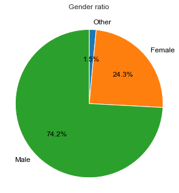

```python
# plot gender
plt.figure(figsize = [10, 5])

gender = df_all.groupby("member_gender").size()
sorted_counts = gender.sort_values()
plt.pie(sorted_counts, labels = sorted_counts.index, startangle = 90, counterclock = False, autopct = '%1.1f%%',
       textprops=dict(color = "black", size = 12))

plt.axis("square")
plt.title("Gender ratio", y = 1.05);
```

> More than 70% of user are male. what about a user type?

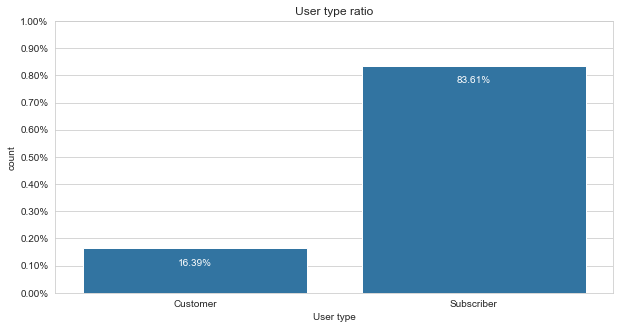

```python
# check customer type
# get base blue color
plt.figure(figsize = [10, 5])
base_color = sns.color_palette()[0]
sns.countplot(data = df_all, x = "user_type", color = base_color)


# create % annot

n_point = df_all.shape[0]
cat_counts = df_all["user_type"].value_counts()
# get the current x location and label
locs, labels = plt.xticks()

# loop through each pair of location and label
for loc, label in zip(locs, labels):
    count = cat_counts[label.get_text()]
    pct_string = '{:0.2f}%'.format(100 * count / n_point)
    plt.text(loc, count-150000, pct_string, ha = 'center', color = 'w')

# get % in y axis
max_counts = df_all["user_type"].value_counts().max()
max_prop = max_counts / n_point
tick_props = np.arange(0, max_prop + 0.2, 0.1)
tick_names = ['{:0.2f}%'.format(v) for v in tick_props]
plt.yticks(tick_props * n_point, tick_names)
plt.xlabel("User type")
plt.title("User type ratio");
```

> More than 80% of people are subscriber (pass-holders). Now I will check how many % of people use the Bike share for all trip service.

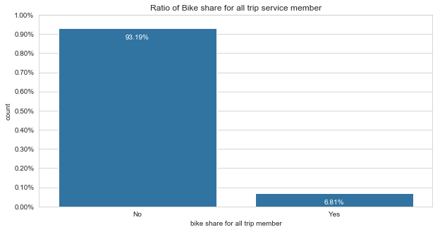

```python
# bike share service
plt.figure(figsize = [10, 5])
base_palette = sns.color_palette()[0]
sns.countplot(data = df_all, x = "bike_share_for_all_trip", color = base_color)

# get % y axis

n_point = df_all.shape[0]
max_count = df_all["bike_share_for_all_trip"].value_counts().max()
max_prop = max_count / n_point

tick_props = np.arange(0, max_prop + 0.1, 0.1)
tcik_names = ['{:0.2f}%'.format(v) for v in tick_props]
plt.yticks(tick_props * n_point, tick_names)

# get x %
cat_counts = df_all["bike_share_for_all_trip"].value_counts()
locs, labels = plt.xticks()

for loc, label in zip(locs, labels):
    count = cat_counts[label.get_text()]
    pct_string = '{:0.2f}%'.format(100 * count / n_point)
    plt.text(loc, count - 140000, pct_string, ha = "center", color = "w")

plt.xlabel("bike share for all trip member")
plt.title("Ratio of Bike share for all trip service member");
```

> More than 90% of user is not part of the bike share for all_trip service. This makes sense as the service is only for people who meet with certain requirements. https://www.fordgobike.com/pricing/bikeshareforall

> How old are users of this service?

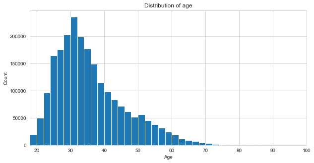

```python
# plot hist
plt.figure(figsize = [10, 5])
bin_edges = np.arange(18, df_all.age.max() +2, 2)

# set lims between 18 years old and 100
plt.xlim(18, 100)
plt.hist(data = df_all, x = "age", bins = bin_edges)
plt.xlabel("Age")
plt.ylabel("Count")
plt.title("Distribution of age");
```

> A peak is around at 30 years old and the distribution is skewed. I will check how long people use a bike per trip.

> How long do they use a bike per trip?

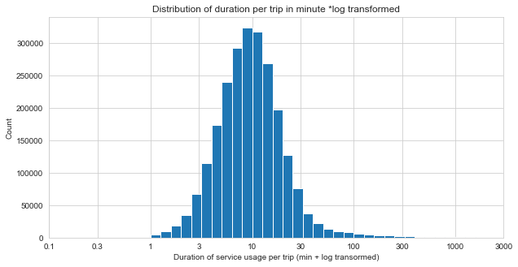

```python
# hist service usage time per trip in log transformation
plt.figure(figsize = [10, 5])

# 1 min bins
bin_edges = 10 ** np.arange(0, np.log10(df_all["duration_min"].max()) + 0.1, 0.1)
# focus on data below 100 min
plt.xscale("log")
plt.hist(data = df_all, x = "duration_min", bins = bin_edges)

tick_locs = [0.1, 0.3, 1, 3, 10, 30, 100, 300, 1000, 3000]
plt.xticks(tick_locs, tick_locs)

plt.xlabel("Duration of service usage per trip (min + log transormed)")
plt.ylabel("Count")
plt.title("Distribution of duration per trip in minute *log transformed");
```

> According to the official website (https://www.fordgobike.com/pricing ), there are 4 major types of pricing.
> 1. 2 dollars per trip / max 30 min
> 2. 10 dollars a day / unlimited 30 min ride
> 3. Member (subscriber):15 dollars a month / unlimited 45min trips
> 4. Bike Share For All 5 dollars for the first year / 60 min trips

> Looking at the price system, it makes sense that a peak is below 30 minutes and there are people who use it for around 40 to 45 minutes as well as around 60 minutes.

> At which weekday do people use the service often?

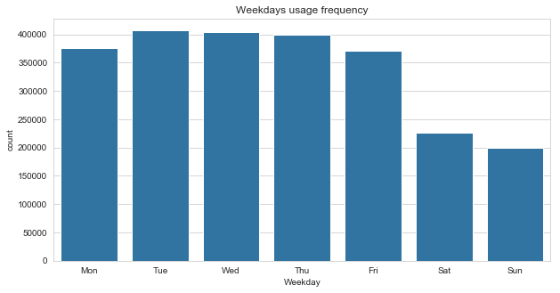

```python
# set category order
plt.figure(figsize = [10, 5])
level_order = ["Mon", "Tue", "Wed", "Thu", "Fri", "Sat", "Sun"]
ordered_cat = pd.api.types.CategoricalDtype(ordered = True, categories = level_order)

# assign the order
df_all["start_weekday"] = df_all["start_weekday"].astype(ordered_cat)

# plot
base_color = sns.color_palette()[0]
sns.countplot(data = df_all, x = "start_weekday", color = base_color)
plt.title("Weekdays usage frequency")
plt.xlabel("Weekday");
```

> There are less users on weekends. Tuesday, Wednesday and Thursday are the most popular weekdays.

> I will look into at which time do people use this service frequently during a day?

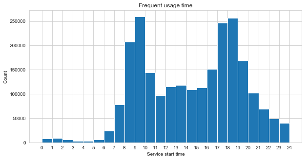

```python
# plot distribution
plt.figure(figsize = [10, 5])
bin_edges = np.arange(0, 24 +1, 1)
plt.hist(data = df_all, x = "start_hour", bins = bin_edges)
plt.xticks(np.arange(0, 24 +1))
plt.title("Frequent usage time")
plt.xlabel("Service start time")
plt.ylabel("Count");
```

> There are 2 obvious peaks which are between 8 to 10 am and between 17 to 19 pm. People may be using this service to commute to work or the University?? I will check if people drive to somewhere in the morning and then use the service again to return to the first place.

> I will compare the two most frequent usage hour of 9am and 18pm.

```python
# plot bike share status at 9am
trip_counts = get_hourly_usage_counts(9)
plot_map(trip_counts)
```

[interactive chart not shown]

```python
# plot bike share status at 6pm
trip_counts = get_hourly_usage_counts(18)
folium_map = plot_map(trip_counts)
folium_map
```

[interactive chart not shown]

> I can see around the bottom left corner that there are more people who borow a bycicle at 9am, but at 18pm there are more people who return it.

Are there any differences on weekdays?

```python
# plot bike share status on Saturday
trip_counts = get_usage_counts_weekday("Sat")
sat = plot_map(trip_counts)
sat
```

[interactive chart not shown]

```python
# plot bike share status on Monday
trip_counts = get_usage_counts_weekday("Tue")
tue = plot_map(trip_counts)
tue
```

[interactive chart not shown]

> On weekday like Tuesday has more blue bubles which shows that more bikes are returned to other places or not yet returned to the same place. However, there are not much differences.

> Are there any changes in frequency of usage overtime?

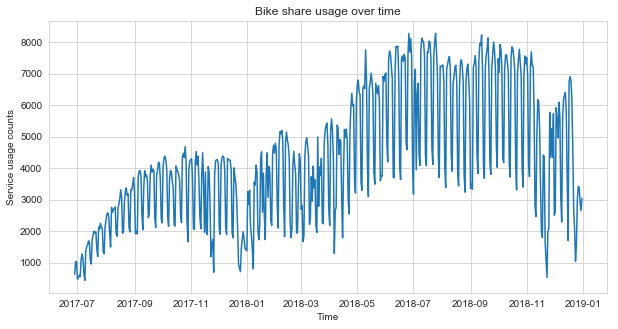

```python
# plot frequency of bike share over time
# get average
date = df_all.groupby("start_date").size()

# set longer x axis
plt.figure(figsize=[10, 5])

# plot
sns.lineplot(data = date)

# set title and labels
plt.title("Bike share usage over time")
plt.xlabel("Time")
plt.ylabel("Service usage counts");
```

> Overall Ford Gobike's usage counts increase over time. However, there are less usage in Winter seasons like in December and January.

> Are there any different behaviors in gender?

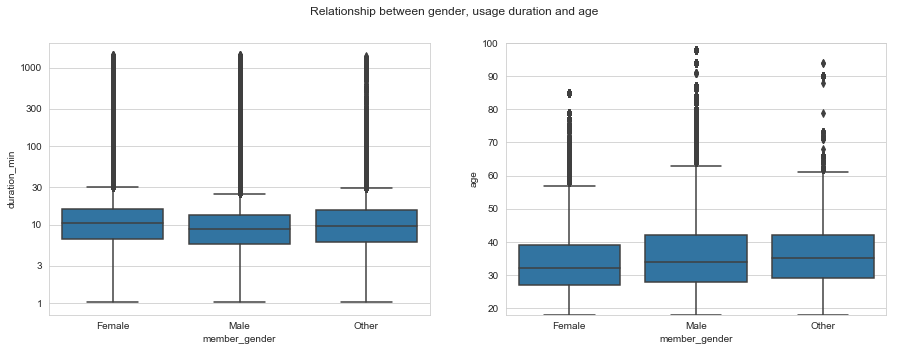

```python
# plot relationship between gender vs duration and gender vs age
base_color = sns.color_palette()[0]

plt.figure(figsize=[15, 5])
plt.subplot(1, 2, 1)
plt.yscale("log")
tick_locs = [0.1, 0.3, 1, 3, 10, 30, 100, 300, 1000, 3000]
plt.yticks(tick_locs, tick_locs)
sns.boxplot(data = df_all, x = "member_gender", y = "duration_min", color = base_color)

plt.subplot(1, 2, 2)
sns.boxplot(data = df_all, x = "member_gender", y = "age", color = base_color)
plt.ylim(18, 100)

plt.suptitle("Relationship between gender, usage duration and age");
```

> There are not much differences. Are there any gender differences in membership?

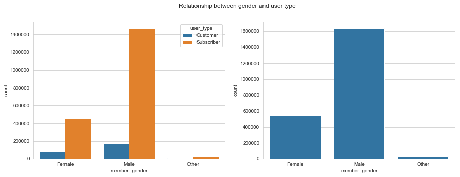

```python
# relationship between gender and user type
plt.figure(figsize=[15, 5])
# left plot
plt.subplot(1, 2, 1)
sns.countplot(data = df_all, x = "member_gender", hue = "user_type" )
plt.title("")
# right plot
plt.subplot(1, 2, 2)
sns.countplot(data = df_all, x = "member_gender", color = base_color)

plt.suptitle("Relationship between gender and user type");
```

> There are also not much differences. I will now check if there are any behavioral differences in user type (member user or not)

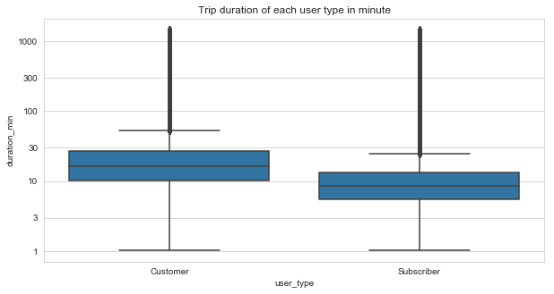

```python
# box plot user type and trip duration
plt.figure(figsize = [10, 5])
plt.yscale("log")
tick_locs = [0.1, 0.3, 1, 3, 10, 30, 100, 300, 1000, 3000]
plt.yticks(tick_locs, tick_locs)
sns.boxplot(data = df_all, x = "user_type", y = "duration_min", color = base_color)
plt.title("Trip duration of each user type in minute");
```

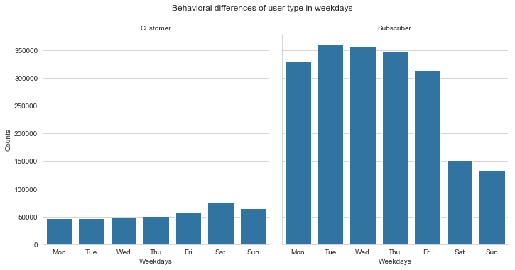

```python
# set category order
level_order = ["Mon", "Tue", "Wed", "Thu", "Fri", "Sat", "Sun"]

# plot
g = sns.FacetGrid(data = df_all, col = "user_type", height = 5)
g.map(sns.countplot, "start_weekday", order = level_order)
g.set_titles('{col_name}')
g.set_ylabels("Counts")
g.set_xlabels("Weekdays")
plt.suptitle("Behavioral differences of user type in weekdays",x = 0.5, y = 1.05, va = "top");
```

> Users without any memberships use a bike longer per trip and more on weekends.

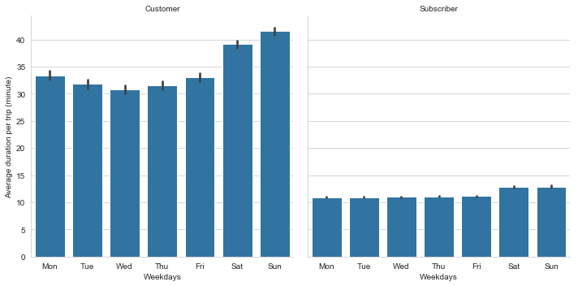

```python
# plot trip time duration of each user type
g = sns.FacetGrid(data = df_all, col = "user_type", height = 5)
g.map(sns.barplot, "start_weekday", "duration_min", order = level_order)
g.set_titles('{col_name}')
g.set_xlabels("Weekdays")
g.set_ylabels("Average duration per trip (minute)");
```

> Member users ride a shared bike for a short time. This makes sense as non-members can use max 30 minutes per trip for 2 dollars and extra 15 minutes for additional 3 dollars. Or 10 dollars for 30 minutes unlimited ride.
> - 2 dollars per trip / max 30 min
> - 10 dollars a day / unlimited 30 min ride
> - Member (subscriber):15 dollars a month / unlimited 45min trips
> - Bike Share For All 5 dollars for the first year / 60 min trips

> https://www.fordgobike.com/pricing

> Are there any differences in what time they start using a shared bike?

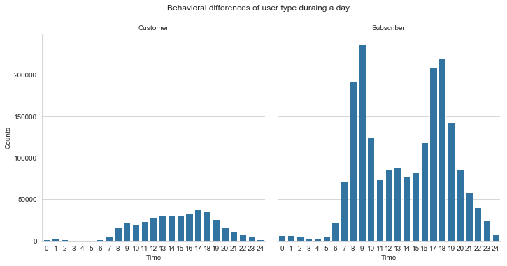

```python
# set category order

level_order = np.arange(0, 25, 1)
g = sns.FacetGrid(data = df_all, col = "user_type", height = 5)
g.map(sns.countplot, "start_hour", order = level_order)
g.set_titles('{col_name}')
g.set_ylabels("Counts")
g.set_xlabels("Time")
plt.suptitle("Behavioral differences of user type duraing a day",x = 0.5, y = 1.05, va = "top");
```

> Whilst there is no trend in the start time for spontaneous users, there is an obvious trend for member users (subscriber).

Are there any behavioral differences in usre type over time?

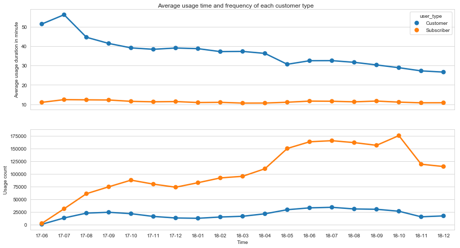

```python
# plot

plt.figure(figsize=[15, 8])
plt.subplot(2, 1, 1)
ax1 = sns.pointplot(data = df_sub2, x = 'start_ym', y = 'avg_duration', hue = 'user_type', linestyles = "-")
plt.xlabel("")
plt.ylabel("Average usage duration in minute")
plt.tick_params(        #https://stackoverflow.com/questions/12998430/remove-xticks-in-a-matplotlib-plot
    axis='x',
    which='both',
    bottom=False,
    top=False,
    labelbottom=False)


plt.subplot(2, 1, 2)
ax2 = sns.pointplot(data = df_sub1, x = 'start_ym', y = 'usage_count', hue = 'user_type', linestyles = "-")
plt.xlabel("Time")
plt.ylabel("Usage count")
ax2.get_legend().set_visible(False)

plt.suptitle("Average usage time and frequency of each customer type", y = 0.90);
```

> The data implicates that over time non-members trip duration tends to decrease. Pass-holders use this service more frequently over time. It would be interesting to see any correlation between weather or temperature and usage duration per trip and usage counts.